# GTGLBSPRDome_SimulateEstimate.R

Colm Fitzgerald

9/22/2021

## GTG-LBSPR dome-shaped selectivity demonstration

We demonstrate the dome-shaped selectivity adjustment to LB-SPR methodology described in the paper “Dome-shaped selectivity in LB-SPR: Length-Based assessment of data-limited inland fish stocks sampled with gillnets” found at https://www.sciencedirect.com/science/article/pii/S0165783620300916 with a simple example.

### Alternative resources

The development of the GTG-LBSPR methodology is described by Hordyk and Prince in the papers

- Hordyk *et al.* (2015) “A novel length-based empirical estimation method…” https://doi.org/10.1093/icesjms/fsu004 and
- Hordyk *et al.* (2016) “A simple length-structured model based on life history ratios…” https://doi.org/10.1139/cjfas-2015-0422.

Adrian Hordyk has shared apps (e.g. https://github.com/AdrianHordyk/LBSPR_shiny) and code (e.g. https://github.com/AdrianHordyk/GTG_LBSPR) on github.

### GTG-LBSPR dome-shaped selectivity - data simulation

We first specify a set of biological stock parameters for a synthetic population

```r
# simulated stock parameters (similar to some Irish brown trout populations) ====
StockPars <- NULL
StockPars$MK <- 2.0
StockPars$NGTG <- 17
StockPars$Linf <- 45.0
StockPars$CVLinf <- 0.1
StockPars$MaxSD <- 2
StockPars$L50 <- 25.0
StockPars$L95 <- 30.0
StockPars$FecB <- 3
StockPars$Walpha <- 0.0084
StockPars$Wbeta <- 3.1115
StockPars$Steepness <- 0.8
StockPars$Mpow <- 0
```

and we also specify the length bins to have an increment of one unit (considered to be centimetres).

```r
SizeBins <- NULL
SizeBins$Linc <- 1
SizeBins$ToSize <- StockPars$Linf*(1+StockPars$MaxSD*StockPars$CVLinf)
```

The fishing gear selectivity parameters are particularly important. Instead of using a range of mesh sizes as in the paper “Dome-shaped selectivity in LBSPR…”, we simply use a single unit mesh size and specify a **lognormal** dome-shaped selection curve.

The dome-shaped selectivity curve has a modal value of `FleetPars$SL1` and has a selectivity-at-length curve as follows

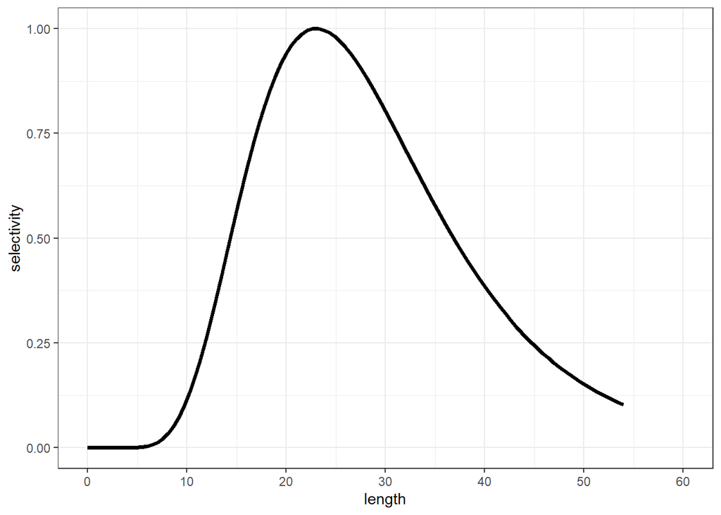

We simulate catch from this population with a prescribed fishing mortality ratio of F/M = `FleetPars$FM <- 1.0` using multinomial random draws. The expected probabilities of a captured fish being from a particular length bin are obtained from the (per-recruit theory) expected catch-at-length for the fished/vulnerable population. This per-recruit theory is implemented in the GTG-LBSPR simulation routine. The length-structure of the fished and unfished catch and total population are shown below.

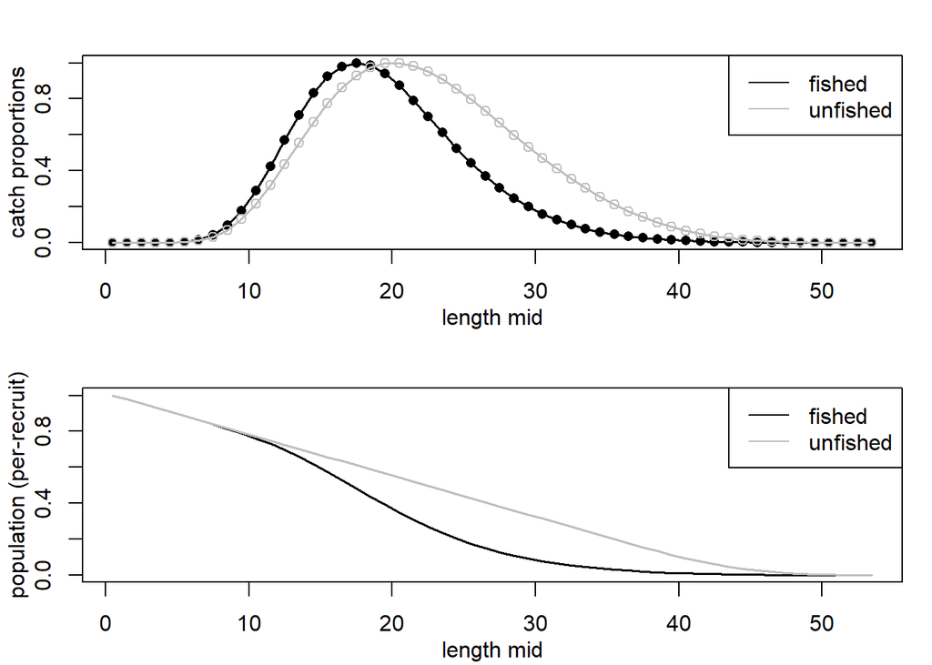

We then generate a random sample of `nFish` fish from a multinomial distribution with expected length bin proportions obtained from the per recruit simulation. A single realisation of the multnomial draw is as follows.

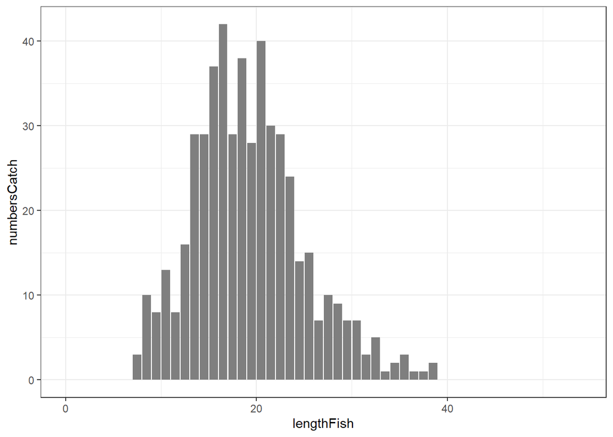

This synthetic data is now used in the estimation model with both correctly specified fishing gear selectivity (dome-shaped) and mis-specified fishing gear selectivity (logistic). It is worth noting the “true” values of fishing mortality and SPR before we compare to the estimation model….

```r
truePars <- list(selectivityCurve = FleetPars$selectivityCurve,
                 SL1 = FleetPars$SL1, SL2 = FleetPars$SL2, SLmesh = FleetPars$SLmesh,
                 SLMin = FleetPars$SLMin,
                 MK = StockPars$MK,
                 FM = FleetPars$FM,
                 SPR = simGTG$SPR)
truePars
```

```
## $selectivityCurve
## [1] "logNorm"
##
## $SL1
## [1] 23
##
## $SL2
## [1] 0.4
##
## $SLmesh
## [1] 1
##
## $SLMin
## [1] 0
##
## $MK
## [1] 2
##
## $FM
## [1] 1
##
## $SPR
## [1] 0.2020115
```

### GTG-LBSPR dome-shaped selectivity - estimation

#### True dome-shaped (lognormal) selectivity curve

We provide correctly specified biological stock parameters and (fixed) fishing gear parameters to the GTG-LBSPR estimation model. The estimation model for dome-shaped selectivity curves estimates **only** the fishing mortality ratio $F/M$. The selectivity-at-length parameters are fixed.

```r
# initialise length bins, stock pars, fishing gear pars
SizeBinsEstimate <- SizeBins
StockParsEstimate <- StockPars
fixedFleetParsEstimate <- FleetPars[c("selectivityCurve", "SL1", "SL2", "SLmesh", "SLMin")]
# estimate FM, calculate SPR with GTG-LBSPR
lbsprEstimate <- DoOptDome(StockPars = StockParsEstimate,
                           fixedFleetPars = fixedFleetParsEstimate,
                           LenDat = sampleCatch$numbersCatch,
                           SizeBins = SizeBinsEstimate, "GTG")
lbsprEstimate$Ests
```

```
##         FM        SL1        SL2     SLmesh      SLMin        SPR
##  1.0912165 23.0000000  0.4000000  1.0000000  0.0000000  0.1773877
```

The estimated fishing mortality ratio and SPR values are reasonably close to the true values for most realisations of the random multinomial draw of `nFish` lengths. More accurate estimation model results can be obtained by increasing the sample size of the simulated catch.

#### Mis-specified selectivity curve - fixed logistic curve

The simulated length data provides a good opportunity to explore the influence of an underlying dome-shaped selectivity on LB-SPR estimates of $F/M$ and SPR when a logistic selection curve is assumed. First, we fully specify a logistic selection curve (i.e, the length-at-50% and 95% selectivity parameters are fixed and not estimated from the model). The logistic selectivity parameters are chosen so that the left (ascending) limb of logistic curve closely follows that of the dome-shaped selectivity curve.

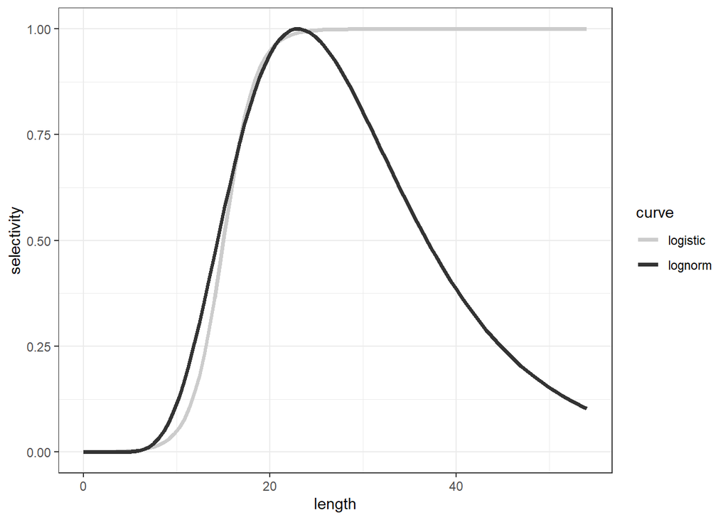

```r
# initialise length bins, stock pars, fishing gear pars
SizeBinsEstimate <- SizeBins
StockParsEstimate <- StockPars
fixedFleetParsLogistic <- FleetParsLogistic[c("selectivityCurve", "SL1", "SL2")]
# estimate FM, calculate SPR with GTG-LBSPR
lbsprLogisticEstimate <- DoOptDome(StockPars = StockParsEstimate,
                           fixedFleetPars = fixedFleetParsLogistic,
                           LenDat = sampleCatch$numbersCatch,
                           SizeBins = SizeBinsEstimate, "GTG")
lbsprLogisticEstimate$Ests
```

```
##         FM        SL1        SL2        SPR
##  1.3886555 15.0000000 20.0000000  0.1015633
```

Parameter estimation and status assessment based on a mis-specified logistic curve clearly illustrates how dome-shaped gear selection may bias estimates of fishing mortality towards higher values and estimates of SPR towards lower values when logistic (trawl-like) selection curves is assumed in the LB-SPR assessment.

#### Mis-specified logistic curve - free selectivity-at-length parameters

```r
# initialise length bins, stock pars, fishing gear pars
SizeBinsEstimate <- SizeBins
StockParsEstimate <- StockPars
fixedFleetParsFullLogistic <- FleetParsLogistic[c("selectivityCurve")] # only fixed parameter is the selectivityCurve
# estimate FM, SL50, SL95, calculate SPR with GTG-LBDPR
lbsprFullLogisticEstimate <- DoOptDome(StockPars = StockParsEstimate,
                           fixedFleetPars = fixedFleetParsFullLogistic,
                           LenDat = sampleCatch$numbersCatch,
                           SizeBins = SizeBinsEstimate, "GTG")
lbsprFullLogisticEstimate$Ests
```

```
##         FM        SL1        SL2        SPR
##  1.2004035 14.4971729 20.4818523  0.1254285
```

We summarise the results in a table.

```r
kable_out
```

| parameters | selectivityCurve | SL1 | SL2 | SLmesh | M/K | F/M | SPR |
| --- | --- | --- | --- | --- | --- | --- | --- |
| true | logNorm | 23.00000 | 0.40000 | 1 | 2 | 1.000000 | 0.2020115 |
| estimated | logNorm | 23.00000 | 0.40000 | 1 | 2 | 1.091217 | 0.1773877 |
| estimated | Logistic | 15.00000 | 20.00000 | 1 | 2 | 1.388656 | 0.1015633 |
| estimated | Logistic | 14.49717 | 20.48185 | 1 | 2 | 1.200403 | 0.1254285 |